# Real-world Data Wrangling

## 1. Gather data

### **1.1.** Problem Statement

The data in these files is a different version of the data in our main U.S. cases and deaths files. Instead of cumulative totals, each file contains the daily number of new cases and deaths, the seven-day rolling average and the seven-day rolling average per 100,000 residents.

https://github.com/nytimes/covid-19-data

### **1.2.** Gather at least two datasets using two different data gathering methods

```python
# import libraries:
import pandas as pd
import numpy as np
import matplotlib.pyplot as plt
%matplotlib inline
import seaborn as sns
from sqlalchemy import create_engine, text
pd.set_option('display.max_colwidth', None)
pd.set_option('display.max_columns', None)
pd.set_option('display.max_rows', None)
```

Load data

```python
#FILL IN 1st data gathering and loading method
# load csv file
df_anomalies = pd.read_csv('anomalies.csv')
df_anomalies.head()
```

|  | date | end_date | county | state | geoid | type | omit_from_rolling_average | omit_from_rolling_average_on_subgeographies | adjusted_daily_count_for_avg | description |
| --- | --- | --- | --- | --- | --- | --- | --- | --- | --- | --- |
| 0 | 2020-04-06 | NaN | New York City | New York | USA-36998 | deaths | NaN | NaN | 0 | The Times began using deaths reported by the New York State Department of Health instead of the city's health department. |
| 1 | 2020-04-09 | NaN | NaN | Wyoming | USA-56 | cases | yes | NaN | 0 | Wyoming began reporting probable cases and deaths. |
| 2 | 2020-04-12 | NaN | NaN | Georgia | USA-13 | both | NaN | NaN | 0 | Our database changed to exclude cases in non-Georgia residents, leading to a one-day drop in the total number of cases. These cases were previously reported with "Unknown" county. |
| 3 | 2020-04-12 | NaN | NaN | Puerto Rico | USA-72 | deaths | NaN | NaN | 0 | Puerto Rico started including some probable Covid-19-related deaths. From April 19 to April 22, the territory stopped reporting probable deaths, and then continued again on April 23. |
| 4 | 2020-04-15 | NaN | NaN | Maryland | USA-24 | deaths | yes | NaN | 0 | Maryland began reporting probable deaths. |

#### **Dataset 1: Anomalies**

Type: csv

Method: Read_csv() - the file was downloaded from website

Dataset variables:

date: The date to which the anomaly applies.  
end_date: The last day to which it applies. Otherwise, left blank.  
geoid: A unique geographic identifier for each place.  
type: Whether the anomaly applies to the data on cases, deaths or both.  
omit_from_rolling_average: This will be yes if the data for that day is excluded from the calculation of rolling averages. Otherwise, left blank.  
adjusted_daily_count_for_avg: If the daily total includes a large known backlog.  
description: A note explaining the cause for the anomaly.

```python
#FILL IN 2nd data gathering and loading method

# load the  file
df_rolling = pd.read_csv('us-counties-recent.csv')
df_rolling.head()
```

|  | date | geoid | county | state | cases | cases_avg | cases_avg_per_100k | deaths | deaths_avg | deaths_avg_per_100k |
| --- | --- | --- | --- | --- | --- | --- | --- | --- | --- | --- |
| 0 | 2023-02-22 | USA-72999 | Unknown | Puerto Rico | -46 | 24.14 | NaN | 0 | 0.0 | NaN |
| 1 | 2023-02-22 | USA-72153 | Yauco | Puerto Rico | 0 | 5.29 | 15.61 | 0 | 0.0 | 0.0 |
| 2 | 2023-02-22 | USA-72151 | Yabucoa | Puerto Rico | 1 | 3.14 | 9.77 | 0 | 0.0 | 0.0 |
| 3 | 2023-02-22 | USA-72149 | Villalba | Puerto Rico | 4 | 1.43 | 6.65 | 0 | 0.0 | 0.0 |
| 4 | 2023-02-22 | USA-72147 | Vieques | Puerto Rico | 0 | 1.00 | 11.96 | 0 | 0.0 | 0.0 |

#### Dataset 2: Rolling Averages

Type: CSV

Dataset variables:

geoid: A unique geographic identifier for each place.  
cases: The number of new cases of Covid-19 reported that day.  
cases_avg: The average number of new cases reported.  
cases_avg_per_100k: The cases_avg per 100,000 people.  
deaths: The total number of new deaths from Covid-19 reported that day.  
deaths_avg: The daily average number of new deaths reported.  
deaths_avg_per_100k: The deaths_avg per 100,000 people.

## 2. Assess data

### Quality Issue 1:

```python
#FILL IN - Inspecting the dataframe visually
df_anomalies.sample(5)
```

|  | date | end_date | county | state | geoid | type | omit_from_rolling_average | omit_from_rolling_average_on_subgeographies | adjusted_daily_count_for_avg | description |
| --- | --- | --- | --- | --- | --- | --- | --- | --- | --- | --- |
| 1983 | 2022-11-11 | NaN | Ochiltree | Texas | USA-48357 | deaths | NaN | NaN | -5 | The Times began including death certificate data reconciled by the C.D.C., resulting in a one-day increase in total deaths. |
| 140 | 2020-11-28 | NaN | NaN | Minnesota | USA-27 | both | NaN | NaN | 0 | Minnesota reported data for two days after reporting no data on Thanksgiving. |
| 1958 | 2022-11-11 | NaN | Lancaster | South Carolina | USA-45057 | deaths | NaN | NaN | -30 | The Times began including death certificate data reconciled by the C.D.C., resulting in a one-day increase in total deaths. |
| 2353 | 2022-11-11 | NaN | Lee | South Carolina | USA-45061 | deaths | NaN | NaN | -20 | The Times began including death certificate data reconciled by the C.D.C., resulting in a one-day increase in total deaths. |
| 1633 | 2022-04-06 | NaN | NaN | Washington | USA-53 | cases | yes | NaN | 0 | Washington added a backlog of cases from testing that occurred earlier in 2022. |

```python
df_anomalies.info()
```

```
<class 'pandas.core.frame.DataFrame'>
RangeIndex: 2511 entries, 0 to 2510
Data columns (total 10 columns):
 #   Column                                       Non-Null Count  Dtype
---  ------                                       --------------  -----
 0   date                                         2511 non-null   object
 1   end_date                                     472 non-null    object
 2   county                                       1776 non-null   object
 3   state                                        2473 non-null   object
 4   geoid                                        2511 non-null   object
 5   type                                         2511 non-null   object
 6   omit_from_rolling_average                    889 non-null    object
 7   omit_from_rolling_average_on_subgeographies  114 non-null    object
 8   adjusted_daily_count_for_avg                 2511 non-null   int64
 9   description                                  2503 non-null   object
dtypes: int64(1), object(9)
memory usage: 196.3+ KB
```

```python
df_anomalies.describe()
```

|  | adjusted_daily_count_for_avg |
| --- | --- |
| count | 2511.000000 |
| mean | -54.752290 |
| std | 933.764802 |
| min | -26236.000000 |
| 25% | -2.000000 |
| 50% | 0.000000 |
| 75% | 0.000000 |
| max | 16677.000000 |

```python
#FILL IN - Inspecting the dataframe programmatically
df_anomalies.shape
```

```
(2511, 10)
```

```python
#Check duplicates in anomalies dataset
df_anomalies.duplicated().sum()
```

```
0
```

```python
#Check duplicates in rolling dataset
df_rolling.duplicated().sum()
```

```
0
```

There are many NA values in some column end_date.

data types of date, end_date are string. They should be converted into datetime

### Quality Issue 2:

```python
df_rolling.shape
```

```
(97702, 10)
```

```python
df_rolling.sample(5)
```

|  | date | geoid | county | state | cases | cases_avg | cases_avg_per_100k | deaths | deaths_avg | deaths_avg_per_100k |
| --- | --- | --- | --- | --- | --- | --- | --- | --- | --- | --- |
| 4298 | 2023-02-23 | USA-40115 | Ottawa | Oklahoma | 19 | 2.71 | 8.72 | 0 | 0.04 | 0.11 |
| 13129 | 2023-02-26 | USA-56001 | Albany | Wyoming | 0 | 5.29 | 13.59 | 0 | 0.00 | 0.00 |
| 41089 | 2023-03-06 | USA-25999 | Unknown | Massachusetts | 0 | 104.14 | NaN | 0 | 0.02 | NaN |
| 17956 | 2023-02-27 | USA-29157 | Perry | Missouri | 0 | 0.57 | 2.99 | 0 | 0.00 | 0.00 |
| 44376 | 2023-03-07 | USA-24017 | Charles | Maryland | 24 | 8.43 | 5.16 | 0 | 0.07 | 0.04 |

```python
#File the negative number in cases column
df_rolling.query("cases < 0").count()["cases"]
```

```
486
```

data types of date is string. It should be converted into datetime

### Tidiness Issue 1:

```python
df_anomalies.sample(5)
```

|  | date | end_date | county | state | geoid | type | omit_from_rolling_average | omit_from_rolling_average_on_subgeographies | adjusted_daily_count_for_avg | description |
| --- | --- | --- | --- | --- | --- | --- | --- | --- | --- | --- |
| 767 | 2021-07-31 | 2021-09-28 | Frontier | Nebraska | USA-31063 | deaths | NaN | NaN | 0 | State and local officials are no longer reporting deaths by county. |
| 1162 | 2021-11-26 | 2021-11-29 | Palm Beach | Florida | USA-12099 | both | NaN | NaN | 0 | Florida did not report new county cases or deaths for the week of Thanksgiving. |
| 814 | 2021-07-31 | 2021-09-19 | Loup | Nebraska | USA-31115 | cases | NaN | NaN | 0 | State and county officials stopped reporting county-level data for several months. |
| 159 | 2020-12-08 | NaN | NaN | Iowa | USA-19 | deaths | yes | NaN | 0 | Iowa changed its methodology for reporting coronavirus deaths to use death certificates, resulting in a one-time increase of deaths previously unreported. |
| 1210 | 2021-12-24 | NaN | NaN | Michigan | USA-26 | both | NaN | NaN | 0 | Michigan did not announce new cases and deaths for the Christmas holiday. |

Column omit_from_rolling_average_on_subgeographies will not use for analyzing data. It should be deleted.

### Tidiness Issue 2:

```python
df_rolling.sample(5)
```

|  | date | geoid | county | state | cases | cases_avg | cases_avg_per_100k | deaths | deaths_avg | deaths_avg_per_100k |
| --- | --- | --- | --- | --- | --- | --- | --- | --- | --- | --- |
| 88552 | 2023-03-21 | USA-48173 | Glasscock | Texas | 0 | 0.00 | 0.00 | 0 | 0.00 | 0.00 |
| 22844 | 2023-03-01 | USA-72065 | Hatillo | Puerto Rico | 3 | 3.43 | 8.83 | 0 | 0.00 | 0.00 |
| 71916 | 2023-03-16 | USA-53013 | Columbia | Washington | 0 | 0.57 | 14.34 | 0 | 0.03 | 0.84 |
| 46816 | 2023-03-08 | USA-38045 | LaMoure | North Dakota | 0 | 0.36 | 8.83 | 0 | 0.00 | 0.00 |
| 19767 | 2023-02-28 | USA-54007 | Braxton | West Virginia | 0 | 1.43 | 10.24 | 0 | 0.00 | 0.00 |

```python
df_rolling.info()
```

```
<class 'pandas.core.frame.DataFrame'>
RangeIndex: 97702 entries, 0 to 97701
Data columns (total 10 columns):
 #   Column               Non-Null Count  Dtype
---  ------               --------------  -----
 0   date                 97702 non-null  object
 1   geoid                97702 non-null  object
 2   county               97702 non-null  object
 3   state                97702 non-null  object
 4   cases                97702 non-null  int64
 5   cases_avg            97702 non-null  float64
 6   cases_avg_per_100k   96660 non-null  float64
 7   deaths               97702 non-null  int64
 8   deaths_avg           97702 non-null  float64
 9   deaths_avg_per_100k  96660 non-null  float64
dtypes: float64(4), int64(2), object(4)
memory usage: 7.5+ MB
```

We can see that, There are NA values in two columns cases_avg_per_100k and deaths_avg_per_100k. They should be 0

## 3. Clean data

Clean the data to solve the 4 issues corresponding to data quality and tidiness found in the assessing step.

Make copies of the datasets

```python
# FILL IN - Make copies of the datasets to ensure the raw dataframes are not impacted
df_anomalies_clean = df_anomalies.copy()
df_rolling_clean = df_rolling.copy()
```

There are many NA values in some column end_date.

Use date to fill end_date column if end_date is NaN so that we can calculate the number of dates between date and end_date.

```python
# FILL na values using start_date to end_date columns
df_anomalies_clean["end_date"] = df_anomalies_clean["end_date"].fillna(df_anomalies_clean["date"])

# FILL na values using string 'No'
df_anomalies_clean["omit_from_rolling_average"] = df_anomalies_clean["omit_from_rolling_average"].fillna("No")
```

```python
# FILL IN - Validate the cleaning was successful
df_anomalies_clean.info()
```

```
<class 'pandas.core.frame.DataFrame'>
RangeIndex: 2511 entries, 0 to 2510
Data columns (total 10 columns):
 #   Column                                       Non-Null Count  Dtype
---  ------                                       --------------  -----
 0   date                                         2511 non-null   object
 1   end_date                                     2511 non-null   object
 2   county                                       1776 non-null   object
 3   state                                        2473 non-null   object
 4   geoid                                        2511 non-null   object
 5   type                                         2511 non-null   object
 6   omit_from_rolling_average                    2511 non-null   object
 7   omit_from_rolling_average_on_subgeographies  114 non-null    object
 8   adjusted_daily_count_for_avg                 2511 non-null   int64
 9   description                                  2503 non-null   object
dtypes: int64(1), object(9)
memory usage: 196.3+ KB
```

```python
df_rolling.query("cases < 0").count()["cases"]
```

```
486
```

```python
#FILL IN - Apply the cleaning strategy
df_rolling_clean['cases'] = df_rolling['cases'].abs()
```

```python
#FILL IN - Validate the cleaning was successful
df_rolling_clean.query("cases < 0").count()["cases"]
```

```
0
```

The abs() function is used to convert negative numbers to positive numbers

Column omit_from_rolling_average_on_subgeographies will not use for analyzing data. It should be deleted.

```python
#Remove column
df_anomalies_clean.drop("omit_from_rolling_average_on_subgeographies", axis = 1, inplace = True)
```

```python
# Validate the removing cloumn was successful
df_anomalies_clean.columns
```

```
Index(['date', 'end_date', 'county', 'state', 'geoid', 'type',
       'omit_from_rolling_average', 'adjusted_daily_count_for_avg',
       'description'],
      dtype='object')
```

Justification: Column omit_from_rolling_average_on_subgeographies will not use for analyzing data. It should be deleted.

Replace NA values in two columns cases_avg_per_100k and deaths_avg_per_100k by 0.

```python
#Fill 0 to na values in columns
df_rolling_clean['cases_avg_per_100k'] = df_rolling_clean['cases_avg_per_100k'].fillna(0)
df_rolling_clean['deaths_avg_per_100k'] = df_rolling_clean['deaths_avg_per_100k'].fillna(0)
```

```python
#FILL IN - Validate the cleaning was successful

df_rolling_clean.head(5)
```

|  | date | geoid | county | state | cases | cases_avg | cases_avg_per_100k | deaths | deaths_avg | deaths_avg_per_100k |
| --- | --- | --- | --- | --- | --- | --- | --- | --- | --- | --- |
| 0 | 2023-02-22 | USA-72999 | Unknown | Puerto Rico | 46 | 24.14 | 0.00 | 0 | 0.0 | 0.0 |
| 1 | 2023-02-22 | USA-72153 | Yauco | Puerto Rico | 0 | 5.29 | 15.61 | 0 | 0.0 | 0.0 |
| 2 | 2023-02-22 | USA-72151 | Yabucoa | Puerto Rico | 1 | 3.14 | 9.77 | 0 | 0.0 | 0.0 |
| 3 | 2023-02-22 | USA-72149 | Villalba | Puerto Rico | 4 | 1.43 | 6.65 | 0 | 0.0 | 0.0 |
| 4 | 2023-02-22 | USA-72147 | Vieques | Puerto Rico | 0 | 1.00 | 11.96 | 0 | 0.0 | 0.0 |

Convert object (String) datatype in data, end_date to datetime

```python
df_rolling_clean['date'] = pd.to_datetime(df_rolling_clean['date'])
df_anomalies_clean['date'] = pd.to_datetime(df_anomalies_clean['date'])
df_anomalies_clean['end_date'] = pd.to_datetime(df_anomalies_clean['end_date'])
```

### **Remove unnecessary variables and combine datasets**

```python
#FILL IN - Remove unnecessary variables and combine datasets
df_rolling_clean.drop(['county'], axis = 1, inplace = True)
```

```python
df_rolling_clean.head()
```

|  | date | geoid | state | cases | cases_avg | cases_avg_per_100k | deaths | deaths_avg | deaths_avg_per_100k |
| --- | --- | --- | --- | --- | --- | --- | --- | --- | --- |
| 0 | 2023-02-22 | USA-72999 | Puerto Rico | 46 | 24.14 | 0.00 | 0 | 0.0 | 0.0 |
| 1 | 2023-02-22 | USA-72153 | Puerto Rico | 0 | 5.29 | 15.61 | 0 | 0.0 | 0.0 |
| 2 | 2023-02-22 | USA-72151 | Puerto Rico | 1 | 3.14 | 9.77 | 0 | 0.0 | 0.0 |
| 3 | 2023-02-22 | USA-72149 | Puerto Rico | 4 | 1.43 | 6.65 | 0 | 0.0 | 0.0 |
| 4 | 2023-02-22 | USA-72147 | Puerto Rico | 0 | 1.00 | 11.96 | 0 | 0.0 | 0.0 |

Remove unnecessary columns

```python
#FILL IN - Remove unnecessary variables and combine datasets
df_anomalies_clean.drop(['county', 'state'], axis = 1, inplace = True)
```

Rename columns before joining 2 datasets

```python
#Rename column date as start_date
df_anomalies_clean = df_anomalies_clean.rename(columns = {'date': 'start_date'})
```

```python
df_anomalies_clean.head(1)
```

|  | start_date | end_date | geoid | type | omit_from_rolling_average | adjusted_daily_count_for_avg | description |
| --- | --- | --- | --- | --- | --- | --- | --- |
| 0 | 2020-04-06 | 2020-04-06 | USA-36998 | deaths | No | 0 | The Times began using deaths reported by the New York State Department of Health instead of the city's health department. |

```python
df_rolling_clean.head(1)
```

|  | date | geoid | state | cases | cases_avg | cases_avg_per_100k | deaths | deaths_avg | deaths_avg_per_100k |
| --- | --- | --- | --- | --- | --- | --- | --- | --- | --- |
| 0 | 2023-02-22 | USA-72999 | Puerto Rico | 46 | 24.14 | 0.0 | 0 | 0.0 | 0.0 |

Merge 2 dataset using inner join method on geoid column

```python
#Merge 2 dataset
df_merge = df_rolling_clean.set_index('geoid').join(df_anomalies_clean.set_index('geoid'), on = "geoid", how = 'inner')
```

```python
df_merge.head(1)
```

| geoid | date | state | cases | cases_avg | cases_avg_per_100k | deaths | deaths_avg | deaths_avg_per_100k | start_date | end_date | type | omit_from_rolling_average | adjusted_daily_count_for_avg | description |
| --- | --- | --- | --- | --- | --- | --- | --- | --- | --- | --- | --- | --- | --- | --- |
| USA-56011 | 2023-02-22 | Wyoming | 0 | 1.0 | 13.19 | 0 | 0.0 | 0.0 | 2022-11-11 | 2022-11-11 | deaths | No | -1 | The Times began including death certificate data reconciled by the C.D.C., resulting in a one-day increase in total deaths. |

```python
df_merge.shape
```

[output not shown]

```python
df_merge.info()
```

[output not shown]

## 4. Update your data store

Update the database/data store with the cleaned data

```python
#FILL IN - saving data
#Save df_rolling_clean
df_rolling_clean.to_csv("rolling_clean.csv")
#Save df_anomalies_clean
df_anomalies_clean.to_csv("anomalies_clean.csv")
#Save df_merge
df_merge.to_csv('merge.csv')
```

```python
#Write data to sqlite
engine = create_engine('sqlite:///us_covid_merge.db')
df_merge.to_sql('covid_merge', engine, index = False, if_exists = 'replace')
```

```
53280
```

## 5. Answer the research question

### **5.1:** Define and answer the research question

- Question 1: What are top 3 states that have the highest number of infected Covid19 cases?

```python
#Visual 1 - FILL IN
# The top 3 states having highest number of cases
top3 = df_merge.groupby('state')['cases'].sum()
top3_plot = top3.sort_values(ascending = False).head(3)
top3_plot
```

```
state
Texas         434147
California    365669
New York      270518
Name: cases, dtype: int64
```

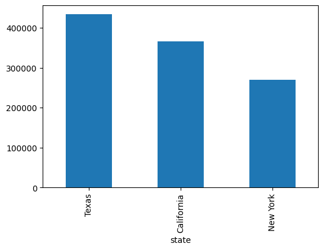

```python
ax = top3_plot.plot.bar(figsize=(6,4), x='State', y='Cases')
```

It can be seen that, In total, Texas has the highest nunber of covid19 cases with 434147 people infected, The second place is California with 365669 people and the third one is New York with 270518 people.

Question 2: What is state that have the highest ratio of deaths/infected cases?

```python
#Visual 2 - FILL IN
#The rate of Deaths/cases

df_rate = df_merge.groupby('state')['cases','deaths'].sum()
df_rate['rate'] = df_rate['deaths'] / df_rate['cases']
df_rate_plot = df_rate.sort_values(by = ['rate'], ascending = False).head(10)
df_rate_plot
```

| state | cases | deaths | rate |
| --- | --- | --- | --- |
| Wyoming | 9 | 2 | 0.222222 |
| Arkansas | 60 | 6 | 0.100000 |
| Connecticut | 2394 | 96 | 0.040100 |
| South Carolina | 2951 | 99 | 0.033548 |
| Oregon | 63 | 2 | 0.031746 |
| Kansas | 637 | 18 | 0.028257 |
| New Hampshire | 118 | 3 | 0.025424 |
| Mississippi | 915 | 22 | 0.024044 |
| Missouri | 11792 | 281 | 0.023830 |
| Utah | 788 | 18 | 0.022843 |

Among states in USA, Wyoming state has the highest ratio of death. There were only 9 infected cases but 2 of them were died. therefore, the ratio is very hight

```python
#Sum number of cases by dates

df_rate = df_merge.groupby('date')['cases'].sum()
df_rate
```

```
date
2023-02-22    119553
2023-02-23     96918
2023-02-24     28100
2023-02-25       914
2023-02-26      1393
2023-02-27     53731
2023-02-28     21774
2023-03-01     76986
2023-03-02     88799
2023-03-03    140465
2023-03-04       896
2023-03-05       882
2023-03-06     44371
2023-03-07     21032
2023-03-08     60334
2023-03-09     73172
2023-03-10     21747
2023-03-11       855
2023-03-12       762
2023-03-13     38106
2023-03-14     17911
2023-03-15    369826
2023-03-16     68995
2023-03-17     39468
2023-03-18       713
2023-03-19       806
2023-03-20     18042
2023-03-21     28503
2023-03-22     53965
2023-03-23     63770
Name: cases, dtype: int64
```

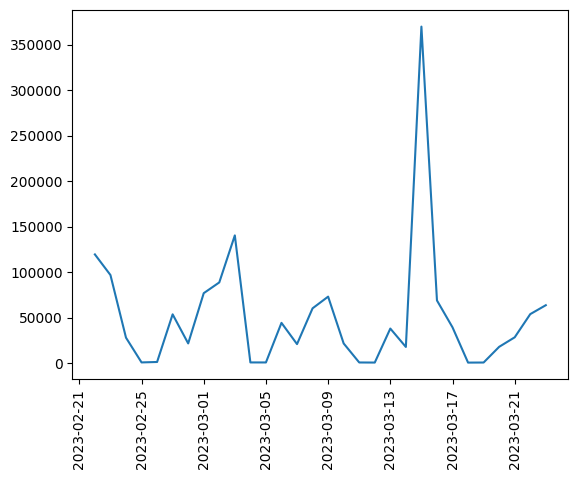

```python
# Create a line plot
plt.plot(df_rate)
plt.xticks(rotation=90)
# Show the plot
plt.show()
```

From the line chart, we can see that, the number of infected cases reaches the peak in 15/3/2023. This may be an anomaly.